# Probability Distributions and Bar Plots

## Overview

- Debugging common errors
- Beautifying your homework
- Probability distribution functions in R
- Plotting binomial distributions with `ggplot2`
- Building on the boxplot: more fun with `ggplot2`

## My homework won't knit! 😖

- When you click "Knit", R instantly forgets all stored datasets and closes all opened packages
- R starts from a clean slate and reads your code top to bottom
- Your code has to run with ZERO ERRORS in order for it to knit!
- Check for errors with "Run" → "Restart R and run all chunks"
- If there is an error, the error message will be written in red

## I can't read in the file! 😭

- You must save your .Rmd document for it to exist somewhere
- Your .csv file needs to be in the same place as the .Rmd (to read it in with only the file name)
- Simple typos in the file name will give you an error like this:

```r
read.csv("Camridge Trees.csv")
```

```
## Error in file(file, "rt"): cannot open the connection
```

## Tips on data management

- Create a folder for Biostats recitation
- Create a separate sub-folder for each week
  - Make a new R Notebook and save it in this folder
  - Save data (.csv files) you need in the same folder

## Beautifying your Homework

## What we're doing to help

- Improved formatting in PS3.Rmd
- Questions as headers, with supporting text in *italics*
- Minimal text—refer to the handout .pdf for more information
- First code chunk that loads packages and sets some options (**edit at your own risk**)

## Tips on code beautification

- Start new lines at natural break points (e.g. after pipes)
- Use indents (you can also "auto-indent" with command + i)

**UGLY:**

```r
chickwts %>% group_by(feed) %>% summarize(mean = mean(weight), sd = sd(weight), range = max(weight) - min(weight))
```

**BEAUTIFUL:**

```r
chickwts %>%
  group_by(feed) %>%
  summarize(mean = mean(weight),
            sd = sd(weight),
            range = max(weight) - min(weight))
```

## Tips on text formatting

- After knitting to Word, make sure to check the formatting; directly edit the .docx to improve readability, if you need to
- After printing, circle your answers if they're hard to find
- Check your rounding! If `round()` isn't working, you can always just write out your answer below in plain text

```r
weights <- c(2,2,3)
mean(weights)
```

```
## [1] 2.333333
```

**mean weight = 2.3 g**

## Probability distributions

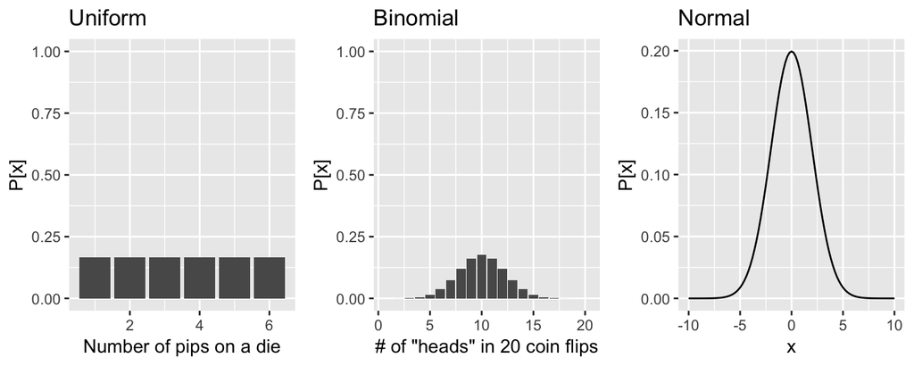

## Probability Distributions in R

- All probability distributions in R have four related functions:
  - A density function that starts with `d` (e.g. `dbinom()`)
  - A distribution function that starts with `p` (e.g. `pbinom()`)
  - A quantile function that starts with a `q` (e.g. `qbinom()`)
  - A random number function that starts with `r` (e.g. `rbinom()`)
- All distributions work similarly
- Today we'll focus on binomial and normal distributions
- Next week we'll introduce the t distribution!

## Binomial Distribution

Number of times one of two mutually exclusive events occurs in n independent trials

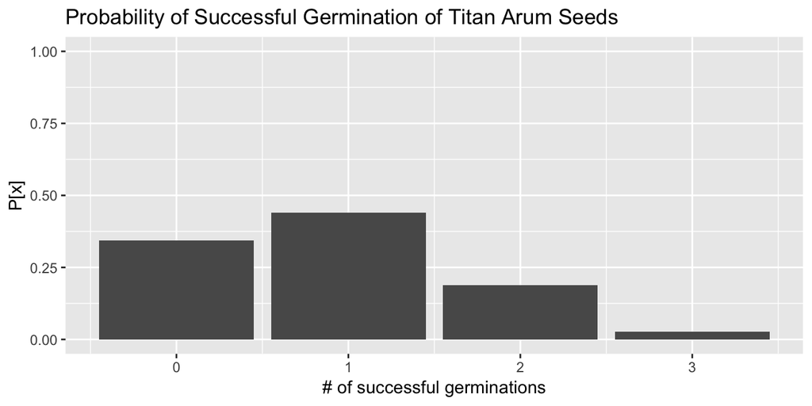

## `*binom()` family of functions

- `dbinom()`, the density function—what's the probability of \([X = 5]\)?
- `pbinom()`, the distribution function—what's the probability of \([X \leq 5]\)?
- `qbinom()`, the quantile function—what quantile is associated with \(P = 0.62\)?
- `rbinom()`, the random function—what's a random number from a binomial distribution with \(n = 10\) and \(p = 0.5\)?

## `*binom()` Think-Pair-Share

- Take a look at the help file for `pbinom()`
  - Which argument is the number of trials?
  - Which argument is binomial p AKA p[success]?
  - What does `lower.tail=FALSE` or `lower.tail=F` do?
  - Which `*binom()` function would you use to figure out the probability of tossing a coin 10 times and getting 5 heads?

## `*binom()` Arguments

- `size =` is \(n\)
- `prob =` is the binomial probability, \(p\)
- `lower.tail =` switches between \(P[X ≤ x]\) (`TRUE`, default) and \(P[X > x]\) (`FALSE`)
- `dbinom()`, the density function, would be used to find the probability of getting 5 heads in 10 coin tosses \(P[X = 5]\)

```r
dbinom(x = 5, size = 10, prob = 0.5) %>% round(4)
```

```
## [1] 0.2461
```

## `pbinom()`, the distribution function

- If you toss a coin 10 times, what's the probability of getting 5 or fewer heads?
- \(P[X \leq 5\) heads\(]\)

```r
pbinom(q = 5, size = 10, prob = 0.5) %>% round(4)
```

```
## [1] 0.623
```

- more than 5 heads?
- \(P[X > 5\) heads\(]\)

```r
pbinom(q = 5, size = 10, prob = 0.5, lower.tail = F) %>% round(4)
```

```
## [1] 0.377
```

## Practice binomial calculations

1. If you roll a single 6-sided die 10 times, what's the probability of rolling a 6 more than once?
2. A study of loggerhead turtles estimates the annual survival probability of juveniles at 0.73. With a starting population of 1000 juvenile turtles, what's the probability that at least 700 will survive?

## Normal Distribution

Defined by mean and standard deviation

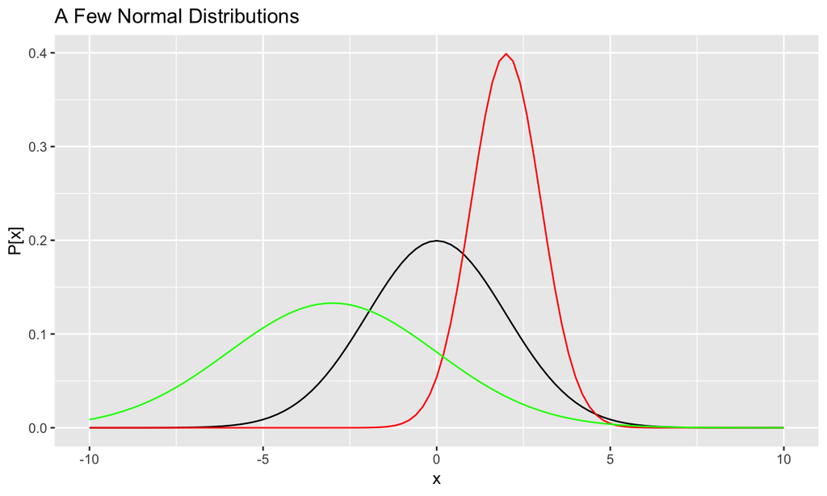